# Milestone Report

Amol Suraj Mishra

11 January 2018

## Loading & Summaries

Dataset for creating swiftkey predictive model https://d396qusza40orc.cloudfront.net/dsscapstone/dataset/Coursera-SwiftKey.zip, containing twitter, news and blog data for 4 languages.

English corpus will be discussed in detail in below sections

```r
enTwitterLines <- readLines("data/final/en_US/en_US.twitter.txt")
enBlogLines <- readLines("data/final/en_US/en_US.blogs.txt")
enNewsLines <- readLines("data/final/en_US/en_US.news.txt")

wordCount <- function(lns){
  sum(sapply(gregexpr("\\S+", lns), length))
}

meanSentenceLength <- function(lns){
  mean(sapply(gregexpr("\\S+", lns), length))
}

lineCount <- function(lns){
  length(lns)
}

tRow <- c(lineCount(enTwitterLines), wordCount(enTwitterLines), meanSentenceLength(enTwitterLines))
bRow <- c(lineCount(enBlogLines), wordCount(enBlogLines), meanSentenceLength(enBlogLines))
nRow <- c(lineCount(enNewsLines), wordCount(enNewsLines), meanSentenceLength(enNewsLines))

infoEn <- rbind(tRow, bRow, nRow)
rownames(infoEn) <- c("twitter", "blog", "news")
colnames(infoEn) <- c("lines", "words", "mean.words.per.line")

infoEn
```

```
##           lines    words mean.words.per.line
## twitter 2360148 30373792            12.86944
## blog     899288 37334441            41.51556
## news      77259  2643972            34.22219
```

## Sampling

In english language, the count of most spoken words wont be above 5000.

Lot of sample extractions methods exist. But they dont work well with this problem. In sense, even if we just take 5% of all datasets we still end up with 5M words to be analyzed. So we defined our own sample extraction method which does sampling randomly.

*Check the utils package to see how sampling is done randomly*

```r
source("utils.R")
set.seed(11081979)

recreate <- FALSE
sampleFactor <- 0.05
info <- createAllSamples("data/final", sampleFactor, recreate)

twitterENInfo <- sampleFile("data/final/en_US/en_US.twitter.txt")
newsENInfo <- sampleFile("data/final/en_US/en_US.news.txt")
blogsENInfo <- sampleFile("data/final/en_US/en_US.blogs.txt")
```

These info objects contain the sample data & some meta information for later purposes

```r
str(twitterENInfo)
```

```
## List of 8
##  $ sample.data          : chr [1:117800] "maybe? just seems they thought up that idea over sunday brunch and thought it was swell." "lo mejor! it was cool experiencing work through the eyes of an excited teen" "#GET BETTER" "Fallout from the original, actually" ...
##  $ org.lines.length     : int [1:2360148] 109 111 40 84 63 77 101 51 54 30 ...
##  $ org.lines.summary    :Classes 'summaryDefault', 'table'  Named num [1:6] 2 37 64 68.7 100 ...
##   .. ..- attr(*, "names")= chr [1:6] "Min." "1st Qu." "Median" "Mean" ...
##  $ org.lines.count      : int 2360148
##  $ org.file.path        : chr "data/final/en_US/en_US.twitter.txt"
##  $ sample.file.path     : chr "data/sample/en_US/en_US.twitter.sample.txt"
##  $ sample.meta.file.path: chr "data/sample/en_US/en_US.twitter.sample.txt.meta"
##  $ locale               : chr "en_US"
```

## Preprocessing

### 1. Tokenization

**Whitespace tokenizer** is used to parse the words. Each line is split into sentences. This is done in order to refrain from the end of sentence being a predictor for the next one. And the tokenizer can be kept independent of the context too. After this, the non word characters are removed. The case is made to lower. And split is done only on basis of whitespace. After all this, we obtain vector of terms.

```r
tokenize <- function(dataset){
  dataset <- unlist(strsplit(dataset, "[\\.\\,!\\?\\:]+"))
  dataset <- tolower(dataset)
  dataset <- gsub("[^a-z\\s]", " ", dataset)
  dataset <- gsub("\\s+", " ", dataset)
  dataset <- trimws(dataset)
  dataset <- strsplit(dataset, "\\s")
  return(dataset)
}
```

```r
twitterSampleENTokenized <- tokenize(twitterENInfo$sample.data)
newsSampleENTokenized <- tokenize(newsENInfo$sample.data)
blogSampleENTokenized <- tokenize(blogsENInfo$sample.data)
```

### 2. Merging

Because all the data we have wroked upon is english, we are merging them into one dataset.

```r
sampleENTokenized <- c(twitterSampleENTokenized, newsSampleENTokenized, blogSampleENTokenized)
```

### 3. Filtering

To remove the most common abusive words for all the languages, we use the following source.

For each language we’ve downloaded a publicly kept profanity list from https://github.com/LDNOOBW/List-of-Dirty-Naughty-Obscene-and-Otherwise-Bad-Words

```r
profanityFilter <- function(termList, locale){
  profanities <- readLines(paste0("data/config/",locale,"/profanity.txt"))
  lapply(termList, setdiff, y=profanities)
}
```

```r
sampleENTokenized <- profanityFilter(sampleENTokenized, twitterENInfo$locale)
```

Stopwords like “the”, “and”, “or” etc. They wont make any useful predictors and removing them might seem a good idea. But on removing them, we will miss out the benefit of them predicting next correct terms. The model in all will be affected to a great extent. And thus they are retained.

## Explore

### 1. View data

The sample tokenized dataset is shown below.

```r
head(sampleENTokenized, 3)
```

```
## [[1]]
## [1] "maybe"
##
## [[2]]
##  [1] "just"    "seems"   "they"    "thought" "up"      "that"    "idea"
##  [8] "over"    "sunday"  "brunch"  "and"     "it"      "was"     "swell"
##
## [[3]]
## [1] "lo"    "mejor"
```

```r
#Num lines
length(sampleENTokenized)
```

```
## [1] 699094
```

```r
#Num terms
sum(sapply(sampleENTokenized, length))
```

```
## [1] 4709171
```

### 2. Term frequencies

Most common words in our dataset can be viewed in the frequencyTable.

```r
frequencyTable <- function(termList){
  term <- data.frame(unlist(termList))
  grouped <- as.data.frame(table(term))
  freq <- grouped[order(-grouped$Freq),]
  rownames(freq) <- 1:nrow(freq)

  total <- sum(freq$Freq)
  freq$CumFreq <- cumsum(freq$Freq)
  freq$Coverage <- freq$CumFreq/total

  return(freq)
}
```

```r
sampleENTermFrequency <- frequencyTable(sampleENTokenized)

head(sampleENTermFrequency, 15)
```

```
##    term   Freq CumFreq   Coverage
## 1   the 175157  175157 0.03719487
## 2    to 115188  290345 0.06165523
## 3   and 104548  394893 0.08385616
## 4     a 102969  497862 0.10572179
## 5    of  85896  583758 0.12396195
## 6     i  74389  658147 0.13975857
## 7    in  73666  731813 0.15540166
## 8   for  51366  783179 0.16630931
## 9    is  50023  833202 0.17693178
## 10 that  47703  880905 0.18706159
## 11   it  44627  925532 0.19653820
## 12  you  43078  968610 0.20568588
## 13   on  38718 1007328 0.21390771
## 14 with  33686 1041014 0.22106099
## 15  was  28703 1069717 0.22715612
```

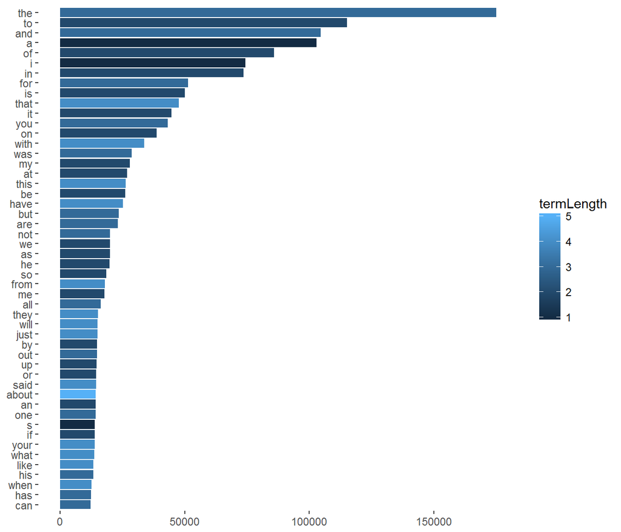

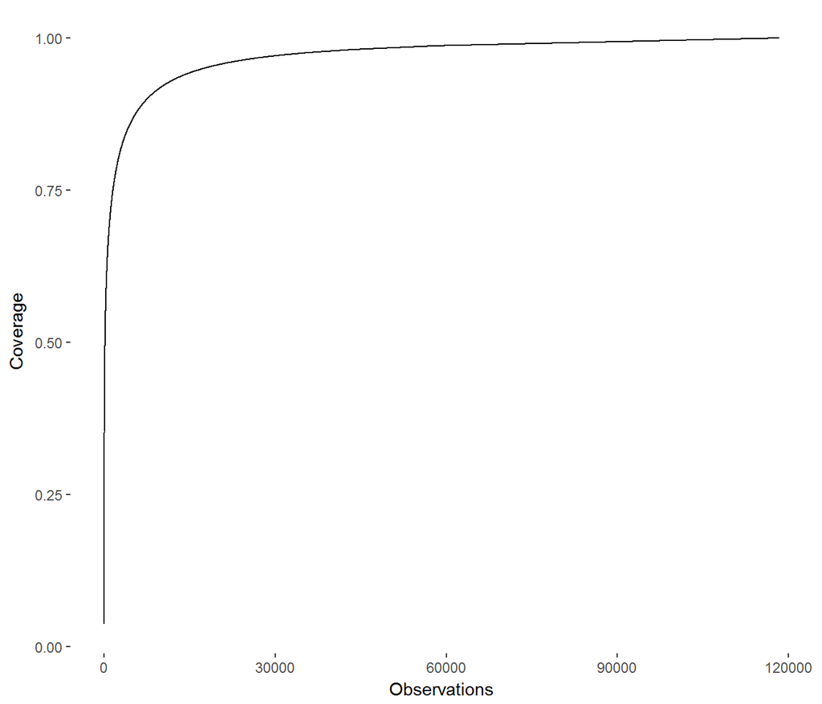

### 3. Check sample

Comparing the above obtained results to the general word frequency dataset from the following source. We downloaded the dataset http://www.wordfrequency.info/top5000.asp

```r
realENWordFrequency <- read.csv("data/config/en_US/word-frequency.csv")
realENWords <- tolower(as.character(unname(realENWordFrequency$Word)))

topLimit <- length(realENWords)

sampleENTermsSlice <- as.character(sampleENTermFrequency$term)[1:topLimit]

#Number of same top frequency words in
numIntersect <- length(intersect(realENWords,sampleENTermsSlice))
numIntersect
```

```
## [1] 2844
```

```r
# Coverage factor
numIntersect/topLimit
```

```
## [1] 0.5688
```

For beginning, coverage factor of 0.57 seems good enough. Increasing sample size may return better results, or validate the top list.

### 4. Create n-grams

Creating n grams…

```r
createNgram <- function(vec, n=2){
  l <- length(vec)
  if(l < n){
    return(c())
  }else if(l == n){
    return(paste(vec, collapse = " "))
  }else{
    numNgrams <- l-n+1
    mtrx <- matrix(nrow=numNgrams, ncol=n)
    for(i in 1:n){
      m <- l - n + i
      mtrx[,i] <- vec[i:m]
    }
    ngrams <- apply(mtrx, 1, paste, collapse=" ")
    return(ngrams)
  }
}

transformNGram <- function(termList, n=2){
  lapply(termList, createNgram, n=n)
}
```

### 5. Bi-gram

```r
sampleENBiGrams <- transformNGram(sampleENTokenized, 2)

sampleENBiGramsFrequency <- frequencyTable(sampleENBiGrams)

head(sampleENBiGramsFrequency, 15)
```

```
##        term  Freq CumFreq    Coverage
## 1    in the 12953   12953 0.003201662
## 2    of the  9824   22777 0.005629913
## 3   for the  7398   30175 0.007458516
## 4     to be  6962   37137 0.009179351
## 5    on the  6784   43921 0.010856188
## 6    to the  6423   50344 0.012443795
## 7    at the  5093   55437 0.013702659
## 8      in a  4628   60065 0.014846587
## 9      is a  4374   64439 0.015927732
## 10   it was  4260   68699 0.016980699
## 11  will be  3828   72527 0.017926886
## 12    for a  3786   76313 0.018862692
## 13 with the  3725   80038 0.019783420
## 14   i have  3688   83726 0.020695003
## 15 going to  3660   87386 0.021599664
```

### 6. Tri-gram

```r
sampleENTriGrams <- transformNGram(sampleENTokenized, 3)

sampleENTriGramsFrequency <- frequencyTable(sampleENTriGrams)

head(sampleENTriGramsFrequency, 15)
```

```
##                  term Freq CumFreq     Coverage
## 1          one of the 1340    1340 0.0003868829
## 2            a lot of 1327    2667 0.0007700125
## 3      thanks for the 1211    3878 0.0011196508
## 4         going to be  759    4637 0.0013387882
## 5             to be a  753    5390 0.0015561933
## 6           i want to  637    6027 0.0017401071
## 7            it was a  624    6651 0.0019202675
## 8          the end of  578    7229 0.0020871468
## 9             i don t  552    7781 0.0022465195
## 10 looking forward to  546    8327 0.0024041599
## 11        some of the  515    8842 0.0025528499
## 12      thank you for  497    9339 0.0026963431
## 13           i have a  488    9827 0.0028372378
## 14         out of the  485   10312 0.0029772663
## 15          i have to  484   10796 0.0031170061
```

### 7. Coverage overview

```r
coverageFactor <- function(freqTable, coverage){
  pos <- nrow(freqTable[freqTable$Coverage < coverage,])
  pos / nrow(freqTable)
}
```

coverage of the n-gram sets compared to the entire corpus

```r
coverageFactors <- c(0.1,0.5,0.9)
uniCov <- sapply(coverageFactors, coverageFactor, freqTable=sampleENTermFrequency)
biCov <- sapply(coverageFactors, coverageFactor, freqTable=sampleENBiGramsFrequency)
triCov <- sapply(coverageFactors, coverageFactor, freqTable=sampleENTriGramsFrequency)

infoCov <- rbind(uniCov, biCov, triCov)
rownames(infoCov) <- c("uni-gram", "bi-gram", "tri-gram")
colnames(infoCov) <- coverageFactors

infoCov
```

```
##                   0.1        0.5        0.9
## uni-gram 2.535111e-05 0.00136896 0.06350454
## bi-gram  1.871362e-04 0.02698157 0.69471748
## tri-gram 3.698060e-03 0.32330239 0.86466016
```

# Evaluation

## 1. Prediction

As evident from the above exploration, small parts of data are responsible for the bulk of the corpus. Thus allowing the prediction to be a relatively smaller model, which just focuses on the most important parts.

## 2. Next steps

- Check out if sample size adjustment would make a significant impact on improving prediction.
- Check out if inclusion of stopwords, punctuation, numbers etc make a difference to what extent.
- Using the identified tokens to build a predictive model.
- Wrapping the results and publishing a shiny app on the same!